# Jaime_Pantoja_2436040_WorkShop1_Code

## WORKSHOP 1: DATA ANALYSIS WITH PANDAS

Name: Jaime Pantoja

Student #: 243604

Date: June 10, 2024

We'll start this workshop, by reading the dataset into a dataframe and performing basic analysis to gain first- hand understanding of the dataset we are working on such as what are the minimum and maximum values in the dataset, whether there are NULL values exist in the dataset, etc.

Before we build the models or form any hypothesis, it is important that we gain these useful insights of the dataset. As it will give us a direction of what type of stories could be discovered for the given dataset.

**Pandas library:** Pandas is a python package, which comes very handy while working with data files. It is used for data analysis such as data operation, pre-processing, manipulation and munging.

```python
# Importing the necesary libraries

import pandas as pd
import numpy as np
import matplotlib.pyplot as plt
%matplotlib inline
```

```python
# Loading the dataset to a dataframe

data = pd.read_csv('adult.data.csv')
data.head()
```

|  | age | workclass | fnlwgt | education | education-num | marital-status | occupation | relationship | race | sex | capital-gain | capital-loss | hours-per-week | native-country | class-label |
| --- | --- | --- | --- | --- | --- | --- | --- | --- | --- | --- | --- | --- | --- | --- | --- |
| 0 | 39 | State-gov | 77516 | Bachelors | 13 | Never-married | Adm-clerical | Not-in-family | White | Male | 2174 | 0 | 40 | United-States | <=50K |
| 1 | 50 | Self-emp-not-inc | 83311 | Bachelors | 13 | Married-civ-spouse | Exec-managerial | Husband | White | Male | 0 | 0 | 13 | United-States | <=50K |
| 2 | 38 | Private | 215646 | HS-grad | 9 | Divorced | Handlers-cleaners | Not-in-family | White | Male | 0 | 0 | 40 | United-States | <=50K |
| 3 | 53 | Private | 234721 | 11th | 7 | Married-civ-spouse | Handlers-cleaners | Husband | Black | Male | 0 | 0 | 40 | United-States | <=50K |
| 4 | 28 | Private | 338409 | Bachelors | 13 | Married-civ-spouse | Prof-specialty | Wife | Black | Female | 0 | 0 | 40 | Cuba | <=50K |

```python
# Q1. Use head(2). Head(10), tail(2). Explain your observations

data.head(10)
```

|  | age | workclass | fnlwgt | education | education-num | marital-status | occupation | relationship | race | sex | capital-gain | capital-loss | hours-per-week | native-country | class-label |
| --- | --- | --- | --- | --- | --- | --- | --- | --- | --- | --- | --- | --- | --- | --- | --- |
| 0 | 39 | State-gov | 77516 | Bachelors | 13 | Never-married | Adm-clerical | Not-in-family | White | Male | 2174 | 0 | 40 | United-States | <=50K |
| 1 | 50 | Self-emp-not-inc | 83311 | Bachelors | 13 | Married-civ-spouse | Exec-managerial | Husband | White | Male | 0 | 0 | 13 | United-States | <=50K |
| 2 | 38 | Private | 215646 | HS-grad | 9 | Divorced | Handlers-cleaners | Not-in-family | White | Male | 0 | 0 | 40 | United-States | <=50K |
| 3 | 53 | Private | 234721 | 11th | 7 | Married-civ-spouse | Handlers-cleaners | Husband | Black | Male | 0 | 0 | 40 | United-States | <=50K |
| 4 | 28 | Private | 338409 | Bachelors | 13 | Married-civ-spouse | Prof-specialty | Wife | Black | Female | 0 | 0 | 40 | Cuba | <=50K |
| 5 | 37 | Private | 284582 | Masters | 14 | Married-civ-spouse | Exec-managerial | Wife | White | Female | 0 | 0 | 40 | United-States | <=50K |
| 6 | 49 | Private | 160187 | 9th | 5 | Married-spouse-absent | Other-service | Not-in-family | Black | Female | 0 | 0 | 16 | Jamaica | <=50K |
| 7 | 52 | Self-emp-not-inc | 209642 | HS-grad | 9 | Married-civ-spouse | Exec-managerial | Husband | White | Male | 0 | 0 | 45 | United-States | >50K |
| 8 | 31 | Private | 45781 | Masters | 14 | Never-married | Prof-specialty | Not-in-family | White | Female | 14084 | 0 | 50 | United-States | >50K |
| 9 | 42 | Private | 159449 | Bachelors | 13 | Married-civ-spouse | Exec-managerial | Husband | White | Male | 5178 | 0 | 40 | United-States | >50K |

```python
data.head(2)
```

|  | age | workclass | fnlwgt | education | education-num | marital-status | occupation | relationship | race | sex | capital-gain | capital-loss | hours-per-week | native-country | class-label |
| --- | --- | --- | --- | --- | --- | --- | --- | --- | --- | --- | --- | --- | --- | --- | --- |
| 0 | 39 | State-gov | 77516 | Bachelors | 13 | Never-married | Adm-clerical | Not-in-family | White | Male | 2174 | 0 | 40 | United-States | <=50K |
| 1 | 50 | Self-emp-not-inc | 83311 | Bachelors | 13 | Married-civ-spouse | Exec-managerial | Husband | White | Male | 0 | 0 | 13 | United-States | <=50K |

```python
data.tail(2)
```

|  | age | workclass | fnlwgt | education | education-num | marital-status | occupation | relationship | race | sex | capital-gain | capital-loss | hours-per-week | native-country | class-label |
| --- | --- | --- | --- | --- | --- | --- | --- | --- | --- | --- | --- | --- | --- | --- | --- |
| 32559 | 22 | Private | 201490 | HS-grad | 9 | Never-married | Adm-clerical | Own-child | White | Male | 0 | 0 | 20 | United-States | <=50K |
| 32560 | 52 | Self-emp-inc | 287927 | HS-grad | 9 | Married-civ-spouse | Exec-managerial | Wife | White | Female | 15024 | 0 | 40 | United-States | >50K |

#### Q1: Observations

When using the .head(x) function and putting a value in the parenthesis it will show the first x instances of the data frame. For example, when entering the data.head(10) it will show the first 10 observations of the dataframe. In the same way the .tail(x) function shows the last x values dataset.

```python
data.shape
```

```
(32561, 15)
```

## Generating your Unique dataset

```python
# My student number is 2436040, therefore I use the last three digits excluding the zero 40.

data = data.sample(n=30000, random_state= 40)
```

```python
data.shape
```

```
(30000, 15)
```

```python
# This code creates a frequency table.

data['education-num'].value_counts()
```

```
9     9650
10    6744
13    4946
14    1590
11    1266
7     1085
12     976
6      848
4      604
15     525
5      476
8      403
16     384
3      307
2      151
1       45
Name: education-num, dtype: int64
```

```python
# This code creates a frequency table.

data['education'].value_counts()
```

```
 HS-grad         9650
 Some-college    6744
 Bachelors       4946
 Masters         1590
 Assoc-voc       1266
 11th            1085
 Assoc-acdm       976
 10th             848
 7th-8th          604
 Prof-school      525
 9th              476
 12th             403
 Doctorate        384
 5th-6th          307
 1st-4th          151
 Preschool         45
Name: education, dtype: int64
```

```python
# It described only a few attributes (numerical ones). If you want to include them all then
# data.describe (include = 'all')

data.describe()
```

|  | age | fnlwgt | education-num | capital-gain | capital-loss | hours-per-week |
| --- | --- | --- | --- | --- | --- | --- |
| count | 30000.000000 | 3.000000e+04 | 30000.000000 | 30000.000000 | 30000.000000 | 30000.000000 |
| mean | 38.588200 | 1.895617e+05 | 10.082533 | 1072.497633 | 87.037633 | 40.408333 |
| std | 13.646239 | 1.054008e+05 | 2.572070 | 7314.591621 | 401.602718 | 12.333148 |
| min | 17.000000 | 1.228500e+04 | 1.000000 | 0.000000 | 0.000000 | 1.000000 |
| 25% | 28.000000 | 1.177962e+05 | 9.000000 | 0.000000 | 0.000000 | 40.000000 |
| 50% | 37.000000 | 1.782045e+05 | 10.000000 | 0.000000 | 0.000000 | 40.000000 |
| 75% | 48.000000 | 2.368860e+05 | 12.000000 | 0.000000 | 0.000000 | 45.000000 |
| max | 90.000000 | 1.484705e+06 | 16.000000 | 99999.000000 | 4356.000000 | 99.000000 |

```python
# Remove a column in a dataset
    # axis 1 removes the column

data = data.drop(['fnlwgt'], axis = 1)
```

```python
data.shape
```

```
(30000, 14)
```

```python
data.describe(include='all')
```

|  | age | workclass | education | education-num | marital-status | occupation | relationship | race | sex | capital-gain | capital-loss | hours-per-week | native-country | class-label |
| --- | --- | --- | --- | --- | --- | --- | --- | --- | --- | --- | --- | --- | --- | --- |
| count | 30000.000000 | 30000 | 30000 | 30000.000000 | 30000 | 30000 | 30000 | 30000 | 30000 | 30000.000000 | 30000.000000 | 30000.000000 | 30000 | 30000 |
| unique | NaN | 9 | 16 | NaN | 7 | 15 | 6 | 5 | 2 | NaN | NaN | NaN | 41 | 2 |
| top | NaN | Private | HS-grad | NaN | Married-civ-spouse | Prof-specialty | Husband | White | Male | NaN | NaN | NaN | United-States | <=50K |
| freq | NaN | 20910 | 9650 | NaN | 13806 | 3828 | 12168 | 25616 | 20067 | NaN | NaN | NaN | 26884 | 22762 |
| mean | 38.588200 | NaN | NaN | 10.082533 | NaN | NaN | NaN | NaN | NaN | 1072.497633 | 87.037633 | 40.408333 | NaN | NaN |
| std | 13.646239 | NaN | NaN | 2.572070 | NaN | NaN | NaN | NaN | NaN | 7314.591621 | 401.602718 | 12.333148 | NaN | NaN |
| min | 17.000000 | NaN | NaN | 1.000000 | NaN | NaN | NaN | NaN | NaN | 0.000000 | 0.000000 | 1.000000 | NaN | NaN |
| 25% | 28.000000 | NaN | NaN | 9.000000 | NaN | NaN | NaN | NaN | NaN | 0.000000 | 0.000000 | 40.000000 | NaN | NaN |
| 50% | 37.000000 | NaN | NaN | 10.000000 | NaN | NaN | NaN | NaN | NaN | 0.000000 | 0.000000 | 40.000000 | NaN | NaN |
| 75% | 48.000000 | NaN | NaN | 12.000000 | NaN | NaN | NaN | NaN | NaN | 0.000000 | 0.000000 | 45.000000 | NaN | NaN |
| max | 90.000000 | NaN | NaN | 16.000000 | NaN | NaN | NaN | NaN | NaN | 99999.000000 | 4356.000000 | 99.000000 | NaN | NaN |

```python
# Creates a frequency table showing the occurance of each feature in the dataset

data['education'].value_counts()
```

```
 HS-grad         9650
 Some-college    6744
 Bachelors       4946
 Masters         1590
 Assoc-voc       1266
 11th            1085
 Assoc-acdm       976
 10th             848
 7th-8th          604
 Prof-school      525
 9th              476
 12th             403
 Doctorate        384
 5th-6th          307
 1st-4th          151
 Preschool         45
Name: education, dtype: int64
```

```python
# It indicates the number of unique values in the selected column

data['education'].nunique()
```

```
16
```

```python
# Sometimes, the values are continuous so the frequency table is not
# the best option to understand the data, so we can use graphs to plot it

data['age'].value_counts()
```

```
36    821
31    820
23    817
35    817
34    810
     ...
84      9
83      4
88      3
85      2
87      1
Name: age, Length: 72, dtype: int64
```

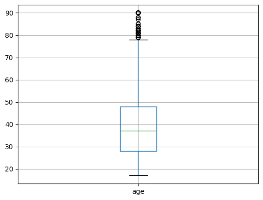

```python
data.boxplot(column='age')
```

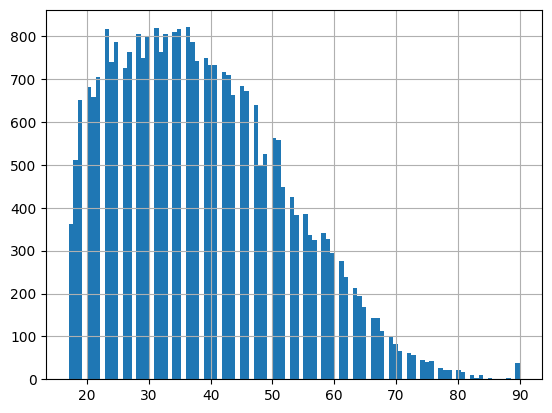

```python
data['age'].hist(bins=100)
```

```python
data['sex'].value_counts()
```

```
 Male      20067
 Female     9933
Name: sex, dtype: int64
```

```python
# To get access to the column labels/ Headers of a DataFrame
data.columns
```

```
Index(['age', 'workclass', 'education', 'education-num', 'marital-status',
       'occupation', 'relationship', 'race', 'sex', 'capital-gain',
       'capital-loss', 'hours-per-week', 'native-country', 'class-label'],
      dtype='object')
```

```python
data['workclass'].value_counts()
```

```
 Private             20910
 Self-emp-not-inc     2355
 Local-gov            1939
 ?                    1676
 State-gov            1195
 Self-emp-inc         1034
 Federal-gov           873
 Without-pay            12
 Never-worked            6
Name: workclass, dtype: int64
```

#### Q2: How many males and females exist in the dataset?

```python
malesAndFemales = data['sex'].value_counts()
total_males_females = data['sex'].count()

print(f'The total value of males and females is: {total_males_females}\n')
print(f'The values by category are: \n{malesAndFemales} ' )
```

```
The total value of males and females is: 30000

The values by category are:
 Male      20067
 Female     9933
Name: sex, dtype: int64
```

## Applying groupby functions in order to summarise the data

Groupby functions are usually used with aggregate functions, which are useful to summarise the dataset and make observations. Some common functions are SUM, MEAN, MAX, MIN and COUNT. Using groupby, we can answer questions as:

**Question: What is the average age of each gender in the given population?**

```python
data['age'].groupby([data['sex']]).mean()
```

```
sex
 Female    36.902547
 Male      39.422584
Name: age, dtype: float64
```

**Question. What is the average age of male and female across different education categories**

```python
data['age'].groupby([data['sex'], data['education']]).mean()
```

```
sex      education
 Female   10th            35.609665
          11th            30.919598
          12th            29.708955
          1st-4th         48.744186
          5th-6th         44.727273
          7th-8th         50.181208
          9th             42.290076
          Assoc-acdm      36.268421
          Assoc-voc       37.635165
          Bachelors       35.698803
          Doctorate       45.187500
          HS-grad         38.697212
          Masters         42.843813
          Preschool       42.923077
          Prof-school     39.734940
          Some-college    33.870918
 Male     10th            38.419689
          11th            33.393013
          12th            32.955390
          1st-4th         45.240741
          5th-6th         42.269565
          7th-8th         48.189011
          9th             40.950725
          Assoc-acdm      37.993289
          Assoc-voc       38.836005
          Bachelors       40.292272
          Doctorate       48.236842
          HS-grad         39.118242
          Masters         44.596171
          Preschool       42.812500
          Prof-school     45.683258
          Some-college    36.948322
Name: age, dtype: float64
```

#### Q3: What is the average contribution to capital-gain of each sex and ocupation category?

Average contribution to capital-gain by sex and ocupation category

```python
data['capital-gain'].groupby([ data['sex'], data['occupation'] ]).mean()
```

```
sex      occupation
 Female   ?                     317.032175
          Adm-clerical          491.132822
          Craft-repair          781.023923
          Exec-managerial       972.496726
          Farming-fishing      1200.660714
          Handlers-cleaners     160.136691
          Machine-op-inspct     169.383399
          Other-service         150.400729
          Priv-house-serv       321.125000
          Prof-specialty       1271.600852
          Protective-serv      1734.301370
          Sales                 287.620748
          Tech-support          695.170418
          Transport-moving      397.741176
 Male     ?                     901.248619
          Adm-clerical          497.407276
          Armed-Forces            0.000000
          Craft-repair          665.427728
          Exec-managerial      2617.481250
          Farming-fishing       539.569767
          Handlers-cleaners     281.246858
          Machine-op-inspct     389.180660
          Other-service         237.034909
          Priv-house-serv        74.250000
          Prof-specialty       3603.102066
          Protective-serv       612.878327
          Sales                1845.870337
          Tech-support          683.017013
          Transport-moving      473.592219
Name: capital-gain, dtype: float64
```

#### Q4: Identify the average capital gain by males and females accross different marital-status

```python
data['capital-gain'].groupby([data['sex'], data['marital-status']]).mean()
```

```
sex      marital-status
 Female   Divorced                  413.217621
          Married-AF-spouse         204.076923
          Married-civ-spouse       1632.430921
          Married-spouse-absent     343.931579
          Never-married             341.399682
          Separated                 194.157986
          Widowed                   507.450649
 Male     Divorced                 1137.567137
          Married-AF-spouse         810.888889
          Married-civ-spouse       1785.675322
          Married-spouse-absent    1000.668367
          Never-married             408.054288
          Separated                 649.019718
          Widowed                  1009.166667
Name: capital-gain, dtype: float64
```

**Question. What is the maximum age accross different races?**

Let's first see what are the different races and then apply groupby

```python
data['race'].value_counts()
```

```
 White                 25616
 Black                  2895
 Asian-Pac-Islander      955
 Amer-Indian-Eskimo      291
 Other                   243
Name: race, dtype: int64
```

```python
data['age'].groupby([data['race']]).max()
```

```
race
 Amer-Indian-Eskimo    82
 Asian-Pac-Islander    90
 Black                 90
 Other                 77
 White                 90
Name: age, dtype: int64
```

#### Q5: Minimum and maximum age by sex are the same?

> Yes, minimum and maximum age by sex are the same

```python
data['age'].groupby([data['sex']]).min()
```

```
sex
 Female    17
 Male      17
Name: age, dtype: int64
```

```python
data['age'].groupby([data['sex']]).max()
```

```
sex
 Female    90
 Male      90
Name: age, dtype: int64
```

## Data visualisation

Matplotlib is a python library for visualising data in the form of graphs such as histograms, scatter, box plot, line plots, heat plots, etc.

```python
# The matplotlib.pyplot should be imported, see the first lines of code

data.describe()
```

|  | age | education-num | capital-gain | capital-loss | hours-per-week |
| --- | --- | --- | --- | --- | --- |
| count | 30000.000000 | 30000.000000 | 30000.000000 | 30000.000000 | 30000.000000 |
| mean | 38.588200 | 10.082533 | 1072.497633 | 87.037633 | 40.408333 |
| std | 13.646239 | 2.572070 | 7314.591621 | 401.602718 | 12.333148 |
| min | 17.000000 | 1.000000 | 0.000000 | 0.000000 | 1.000000 |
| 25% | 28.000000 | 9.000000 | 0.000000 | 0.000000 | 40.000000 |
| 50% | 37.000000 | 10.000000 | 0.000000 | 0.000000 | 40.000000 |
| 75% | 48.000000 | 12.000000 | 0.000000 | 0.000000 | 45.000000 |
| max | 90.000000 | 16.000000 | 99999.000000 | 4356.000000 | 99.000000 |

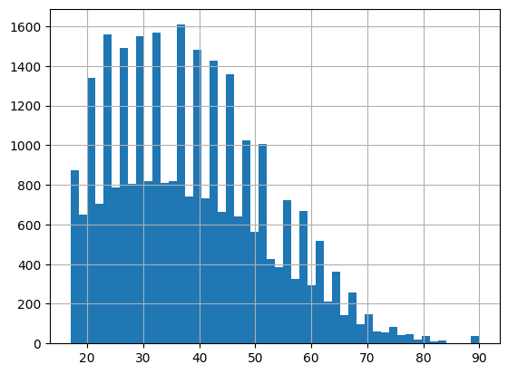

```python
data['age'].hist(bins=50)
```

Histograms are used to represent the distribution of a dataset. The bars of the histogram are known as the bins or "bucket" - the range of values. Bins are of the same width. Width of the bins can be calculated as (max value of data - min value of data)/total number of bins. The bins are usually specified as continuous, non-overlapping intervals of a variable.

In the above figure, histogram with bins = 50 is used to show the number of peopel belongs to different age-groups. Here x-axis represents 'age' and y axis represents 'count.

**Try-it-yourself:** change bins = 100 and run the cell to observe the differences for your own undestanding

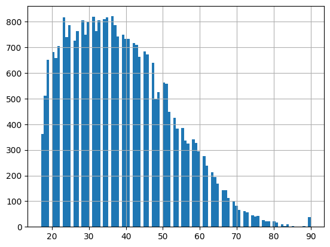

```python
# When the number of bins increases the width of the bins decreases.
# Additionally, it also increments the number of bars in the histogram

data['age'].hist(bins=100)
```

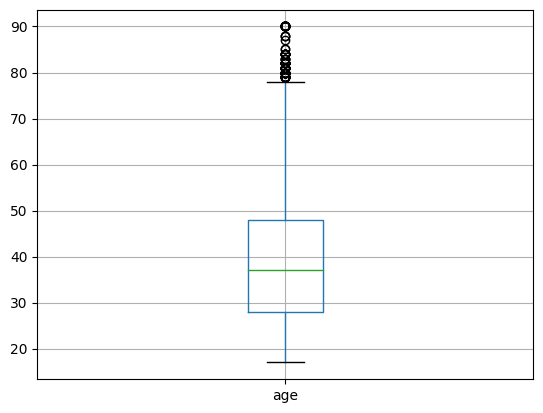

```python
data.boxplot( column='age')
```

In the above figure, boxplot is used to find the average number of people belongs to which age-range group

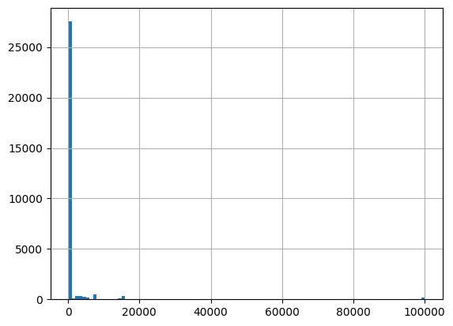

```python
data['capital-gain'].hist(bins=100)
```

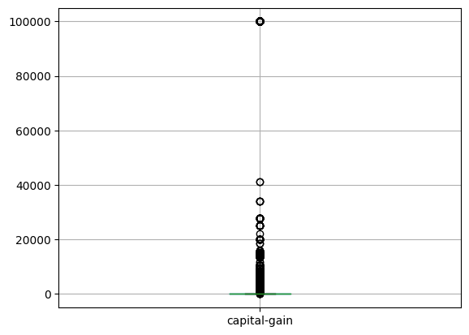

```python
data.boxplot(column='capital-gain')
```

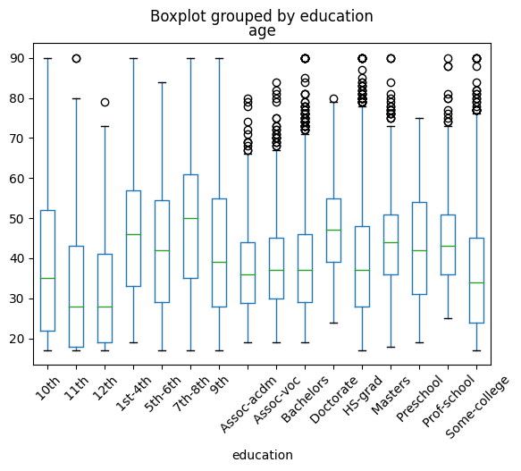

```python
data.boxplot(column='age', by='education', grid=False, rot = 45, fontsize= 10)
```

```python
data['education'].value_counts()
```

```
 HS-grad         9650
 Some-college    6744
 Bachelors       4946
 Masters         1590
 Assoc-voc       1266
 11th            1085
 Assoc-acdm       976
 10th             848
 7th-8th          604
 Prof-school      525
 9th              476
 12th             403
 Doctorate        384
 5th-6th          307
 1st-4th          151
 Preschool         45
Name: education, dtype: int64
```

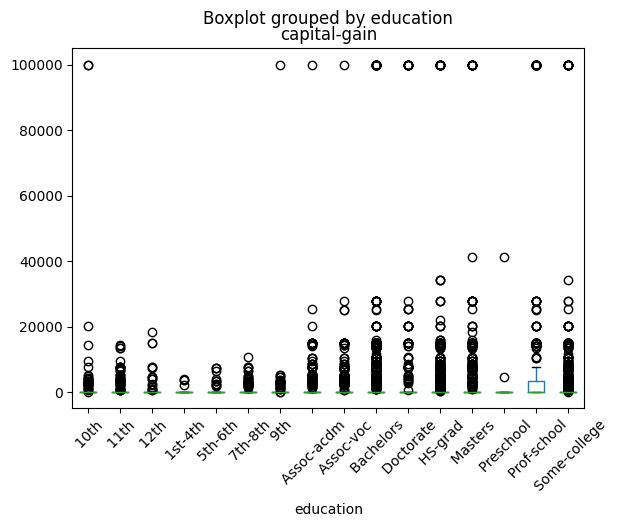

```python
data.boxplot(column='capital-gain', by='education', grid=False, rot = 45, fontsize= 10)
```

After performing some basic data analysis, let's look at data pre-processing to improve the quality of the dataset.

Data pre-processing is an important step in the process. Raw data can be unstructured and full of noise. Aim of this phase is to clean the raw data, reduce noise and to prepare the dataset that can be accepted by the algorithm as an input. Remember garbage in, garbage out!

```python
data['marital-status'].value_counts()
```

```
 Married-civ-spouse       13806
 Never-married             9835
 Divorced                  4094
 Separated                  931
 Widowed                    926
 Married-spouse-absent      386
 Married-AF-spouse           22
Name: marital-status, dtype: int64
```

## Cheking NULL values in the dataset

```python
data.apply(lambda x: sum(x.isnull()), axis=0)
```

```
age               0
workclass         0
education         0
education-num     0
marital-status    0
occupation        0
relationship      0
race              0
sex               0
capital-gain      0
capital-loss      0
hours-per-week    0
native-country    0
class-label       0
dtype: int64
```

You will notice that the missing values are not picked up by this code. As the NULL or missing values are replaced by '?'. It is important that we treat NULL or missing values in our dataset, which is usually done in a data pre-processing phase of data mining. In this workshop, we ignore this step as the values are already being replaced by '?'. In the following workshops, we will see this step in the great details.

## Data transformation

**Label Encoding:**

Some attributes are categorical, therefore (statistical) analysis on those variables is not possible. We need to convert all categorical variables (string labels) into numeric by encoding the categories. Package 'sklearn' provides 'LabelEncoder' library for encoding labels between 0 to n-1 discrete values/labels, where n is the number of values/labels. E.g.:

[output not shown]

```python
from sklearn.preprocessing import LabelEncoder
```

```python
data.head()
```

|  | age | workclass | education | education-num | marital-status | occupation | relationship | race | sex | capital-gain | capital-loss | hours-per-week | native-country | class-label |
| --- | --- | --- | --- | --- | --- | --- | --- | --- | --- | --- | --- | --- | --- | --- |
| 26470 | 40 | Private | Prof-school | 15 | Married-civ-spouse | Prof-specialty | Husband | White | Male | 0 | 0 | 40 | United-States | >50K |
| 1104 | 34 | Self-emp-not-inc | Assoc-acdm | 12 | Married-civ-spouse | Prof-specialty | Wife | White | Female | 0 | 0 | 25 | United-States | >50K |
| 85 | 53 | Private | HS-grad | 9 | Divorced | Sales | Own-child | White | Female | 0 | 0 | 35 | United-States | <=50K |
| 16639 | 39 | Private | Some-college | 10 | Never-married | Machine-op-inspct | Not-in-family | White | Male | 0 | 0 | 40 | United-States | <=50K |
| 28097 | 22 | Private | HS-grad | 9 | Never-married | Machine-op-inspct | Not-in-family | White | Male | 0 | 0 | 50 | United-States | <=50K |

```python
data.dtypes
```

```
age                int64
workclass         object
education         object
education-num      int64
marital-status    object
occupation        object
relationship      object
race              object
sex               object
capital-gain       int64
capital-loss       int64
hours-per-week     int64
native-country    object
class-label       object
dtype: object
```

```python
columns = list(data.select_dtypes(exclude=['int64']))
```

```python
columns
```

```
['workclass',
 'education',
 'marital-status',
 'occupation',
 'relationship',
 'race',
 'sex',
 'native-country',
 'class-label']
```

```python
data['class-label'].value_counts()
```

```
 <=50K    22762
 >50K      7238
Name: class-label, dtype: int64
```

```python
le = LabelEncoder()
for i in columns:
    data[i] = le.fit_transform(data[i])
data.dtypes
```

```
age               int64
workclass         int32
education         int32
education-num     int64
marital-status    int32
occupation        int32
relationship      int32
race              int32
sex               int32
capital-gain      int64
capital-loss      int64
hours-per-week    int64
native-country    int32
class-label       int32
dtype: object
```

```python
data.head()
```

|  | age | workclass | education | education-num | marital-status | occupation | relationship | race | sex | capital-gain | capital-loss | hours-per-week | native-country | class-label |
| --- | --- | --- | --- | --- | --- | --- | --- | --- | --- | --- | --- | --- | --- | --- |
| 26470 | 40 | 4 | 14 | 15 | 2 | 10 | 0 | 4 | 1 | 0 | 0 | 40 | 38 | 1 |
| 1104 | 34 | 6 | 7 | 12 | 2 | 10 | 5 | 4 | 0 | 0 | 0 | 25 | 38 | 1 |
| 85 | 53 | 4 | 11 | 9 | 0 | 12 | 3 | 4 | 0 | 0 | 0 | 35 | 38 | 0 |
| 16639 | 39 | 4 | 15 | 10 | 4 | 7 | 1 | 4 | 1 | 0 | 0 | 40 | 38 | 0 |
| 28097 | 22 | 4 | 11 | 9 | 4 | 7 | 1 | 4 | 1 | 0 | 0 | 50 | 38 | 0 |

```python
data['workclass'].value_counts()
```

```
4    20910
6     2355
2     1939
0     1676
7     1195
5     1034
1      873
8       12
3        6
Name: workclass, dtype: int64
```

You will notice that all the values are now numeric. Now, more computation and analysis can be performed on the dataset.

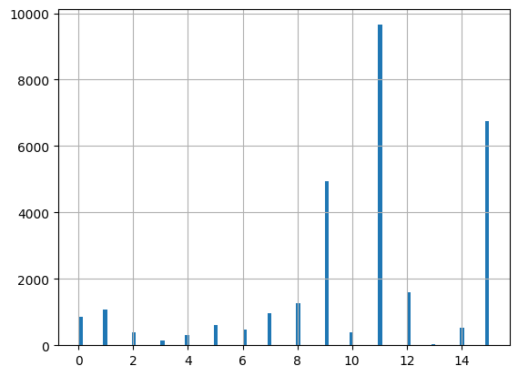

```python
data['education'].hist(bins=100)
```

```python
data.describe(include='all')
```

|  | age | workclass | education | education-num | marital-status | occupation | relationship | race | sex | capital-gain | capital-loss | hours-per-week | native-country | class-label |
| --- | --- | --- | --- | --- | --- | --- | --- | --- | --- | --- | --- | --- | --- | --- |
| count | 30000.000000 | 30000.000000 | 30000.000000 | 30000.000000 | 30000.000000 | 30000.000000 | 30000.000000 | 30000.000000 | 30000.000000 | 30000.000000 | 30000.000000 | 30000.000000 | 30000.000000 | 30000.000000 |
| mean | 38.588200 | 3.872333 | 10.302900 | 10.082533 | 2.611433 | 6.573933 | 1.444333 | 3.664600 | 0.668900 | 1072.497633 | 87.037633 | 40.408333 | 35.765267 | 0.241267 |
| std | 13.646239 | 1.453148 | 3.869175 | 2.572070 | 1.506716 | 4.226614 | 1.606172 | 0.850489 | 0.470617 | 7314.591621 | 401.602718 | 12.333148 | 7.642869 | 0.427859 |
| min | 17.000000 | 0.000000 | 0.000000 | 1.000000 | 0.000000 | 0.000000 | 0.000000 | 0.000000 | 0.000000 | 0.000000 | 0.000000 | 1.000000 | 0.000000 | 0.000000 |
| 25% | 28.000000 | 4.000000 | 9.000000 | 9.000000 | 2.000000 | 3.000000 | 0.000000 | 4.000000 | 0.000000 | 0.000000 | 0.000000 | 40.000000 | 38.000000 | 0.000000 |
| 50% | 37.000000 | 4.000000 | 11.000000 | 10.000000 | 2.000000 | 7.000000 | 1.000000 | 4.000000 | 1.000000 | 0.000000 | 0.000000 | 40.000000 | 38.000000 | 0.000000 |
| 75% | 48.000000 | 4.000000 | 12.000000 | 12.000000 | 4.000000 | 10.000000 | 3.000000 | 4.000000 | 1.000000 | 0.000000 | 0.000000 | 45.000000 | 38.000000 | 0.000000 |
| max | 90.000000 | 8.000000 | 15.000000 | 16.000000 | 6.000000 | 14.000000 | 5.000000 | 4.000000 | 1.000000 | 99999.000000 | 4356.000000 | 99.000000 | 40.000000 | 1.000000 |

## Report

Answer the following questions. You are required to include correct code(s) to answer the questions

#### Q6: Write a summary of the outcome of data.describe().

```python
data.describe()
```

|  | age | workclass | education | education-num | marital-status | occupation | relationship | race | sex | capital-gain | capital-loss | hours-per-week | native-country | class-label |
| --- | --- | --- | --- | --- | --- | --- | --- | --- | --- | --- | --- | --- | --- | --- |
| count | 30000.000000 | 30000.000000 | 30000.000000 | 30000.000000 | 30000.000000 | 30000.000000 | 30000.000000 | 30000.000000 | 30000.000000 | 30000.000000 | 30000.000000 | 30000.000000 | 30000.000000 | 30000.000000 |
| mean | 38.588200 | 3.872333 | 10.302900 | 10.082533 | 2.611433 | 6.573933 | 1.444333 | 3.664600 | 0.668900 | 1072.497633 | 87.037633 | 40.408333 | 35.765267 | 0.241267 |
| std | 13.646239 | 1.453148 | 3.869175 | 2.572070 | 1.506716 | 4.226614 | 1.606172 | 0.850489 | 0.470617 | 7314.591621 | 401.602718 | 12.333148 | 7.642869 | 0.427859 |
| min | 17.000000 | 0.000000 | 0.000000 | 1.000000 | 0.000000 | 0.000000 | 0.000000 | 0.000000 | 0.000000 | 0.000000 | 0.000000 | 1.000000 | 0.000000 | 0.000000 |
| 25% | 28.000000 | 4.000000 | 9.000000 | 9.000000 | 2.000000 | 3.000000 | 0.000000 | 4.000000 | 0.000000 | 0.000000 | 0.000000 | 40.000000 | 38.000000 | 0.000000 |
| 50% | 37.000000 | 4.000000 | 11.000000 | 10.000000 | 2.000000 | 7.000000 | 1.000000 | 4.000000 | 1.000000 | 0.000000 | 0.000000 | 40.000000 | 38.000000 | 0.000000 |
| 75% | 48.000000 | 4.000000 | 12.000000 | 12.000000 | 4.000000 | 10.000000 | 3.000000 | 4.000000 | 1.000000 | 0.000000 | 0.000000 | 45.000000 | 38.000000 | 0.000000 |
| max | 90.000000 | 8.000000 | 15.000000 | 16.000000 | 6.000000 | 14.000000 | 5.000000 | 4.000000 | 1.000000 | 99999.000000 | 4356.000000 | 99.000000 | 40.000000 | 1.000000 |

> The describe function provides the dataset's descriptive statistics, particularly it gives the metrics of count, mean, standard deviation, min, and max. In this dataset, all the variables are numeric after using the LabelEncoder which allows running the describe function in all the table.

> In this example, relevant information regarding age, capital-gain, capital-losses, and other categories is presented. The descriptive statistics provide a general overview that can be further explored by using additional libraries.

#### Q7: What are the different data types (or attribut types) in data mining? Explain with the help of examples from Adult dataset.**HINT:** Don't get confused with data types in Python.

There are different attribute types in data mining. Some authors, like Medium (2022) define mainly five types.

- **Nominal or Categorical attributes:** they reference a category and there is no meaning or order between them. The 'Adult' dataset has categorical attributes like 'workclass', 'marital-status', 'occupation, 'relationship', 'race', 'native-country
- **Binary attributes:** It is the same as a categorical attributes but there are only two values and both have the same weight, for example, the 'sex' attribute where you can find males or females. Another example is the 'class-label' where only two values can be possible <=50k or >50k.
- **Ordinal attributes:** these are attributes that represent certain ranking among them. In this dataset, an example is the attribute of 'education' because there is a ranking among those values, where the instances with a Doctorate have the highest ranking.
- **Numeric attributes:** These are measurable attributes represented by using numbers (int or float) in the 'adults' dataset some examples are 'age', 'education-num, 'capital-gain', 'capital-loss', 'hours-per-week'
- **Discrete and continuous attributes:** Discrete attributes can be counted, for example, the number of students in a classroom. When it comes to continous attributes they represented quantities or measurements that can be represented on a scale, for example, height, time, temperature, etc.

#### Q8: Highest migrants belongs to which countries.

```python
# Load the original data from source file
# Show only the first 10 rows using .head(10)

data2 = pd.read_csv('adult.data.csv')
data2['native-country'].value_counts().head(10)
```

```
 United-States    29170
 Mexico             643
 ?                  583
 Philippines        198
 Germany            137
 Canada             121
 Puerto-Rico        114
 El-Salvador        106
 India              100
 Cuba                95
Name: native-country, dtype: int64
```

> As shown in the table above the higest number of migrants to the US come from Mexico (643), Philippines (198), Germany (137), and Canada (121).

#### Q9: Which opucation represent more males than females.

```python
# Create a series that groups the occupations by sex and counts the values.
# It is sorted by occupation, this to make easier future changes

series = data2.groupby(['sex'])['occupation'].value_counts().sort_index(level=1)

# Transform the series to a dataframe so it is easier to perform operations involving multiple columns

df = series.reset_index(name='count')

# Pivot the DataFrame so we have two columns with the count of Male and Female and the rows represent the ocupation.

# This organization with the goal of filtering the occupation with higher count for males

pivot_df = df.pivot_table(index='occupation', columns='sex', values='count', aggfunc='sum')

# reset the index so the headers of the columns are in the right place

pivot_df = pivot_df.reset_index()

# There is a space in the name of the columns 'Male' and 'Female', we need to fix that to run the conditional filter

pivot_df.columns = pivot_df.columns.str.strip()

# Now the data is filtered showing only the occupations where the count of Males is greater than Females

filtered_df = pivot_df[ pivot_df['Male'] > pivot_df['Female'] ]
filtered_df = filtered_df.sort_values(by='Male', ascending=False)
filtered_df['difference'] = filtered_df['Male'] - filtered_df['Female']
filtered_df.head()
```

| sex | occupation | Female | Male | difference |
| --- | --- | --- | --- | --- |
| 3 | Craft-repair | 222.0 | 3877.0 | 3655.0 |
| 4 | Exec-managerial | 1159.0 | 2907.0 | 1748.0 |
| 10 | Prof-specialty | 1515.0 | 2625.0 | 1110.0 |
| 12 | Sales | 1263.0 | 2387.0 | 1124.0 |
| 14 | Transport-moving | 90.0 | 1507.0 | 1417.0 |

> The occupation that represents more Males than Females is **Craft-repair**, where Males are 3877 and Females are 222. More occupations where males have a higher count are presented in the table above.

#### Q10: What is the difference between data.head() and data.tail().

> The difference between those two functions is that the data.head() shows the first 5 observations in the dataset and the data.tail() shows the last five observations.

**Bibliography:**

Medium (2022) Types of Attributes in Datasets. Available at: https://medium.com/@codeminded/types-of-attributes-in-datasets-de381b1cd30e (Accessed: May 05, 2024).